# RBIF112 - Assignment 3

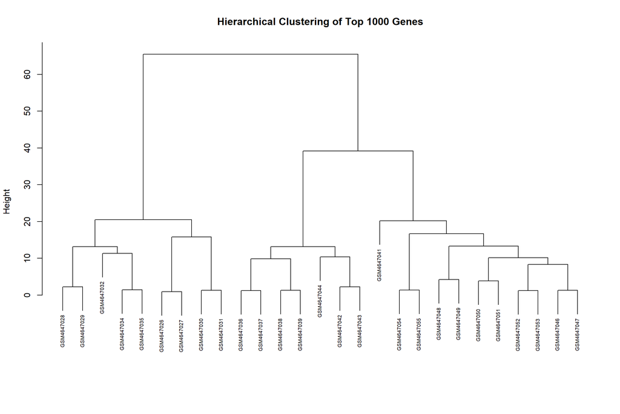

```r
plot_hclust(top1k_genes, "Hierarchical Clustering of Top 1000 Genes")
```

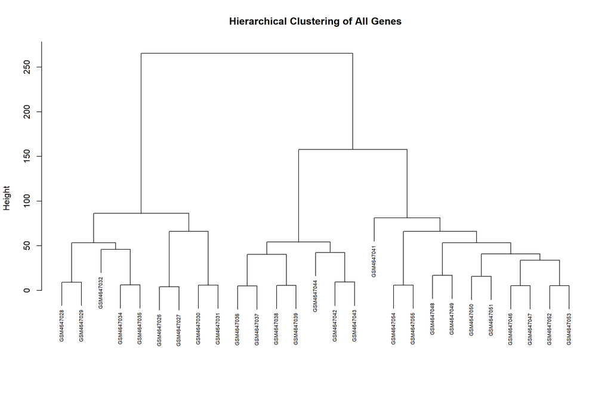

```r
plot_hclust(all_genes, "Hierarchical Clustering of All Genes")
```

# 2 Principal Component Analysis

## 2.1 Analysis on top 100 and top 100 non-normalized data

Using the top 100 and top 1000 genes with highest variance, find the number of principal components accounting for the most variance in the data, e.g. 50% or 75% (total variance is the sum of variances along all PCs; sum of variances of k first principal components is the part they “account” for).  
Describe how much this number of dimensions (explaining most of the variance in the data) changes for different number of genes considered. Examine structure in the data as revealed by visualizing in PC projection. Color points by any annotation features available (e.g. treatment, sex, batch, etc.) in a scatter plot (a 3D scatter plot will be best). Describe your findings.

```r
### Perform PCA ###

## perform PCA on the top 100 genes
# scale the top100 data
top100_scaled <- scale(top100_genes)
# perform PCA
top100_pca <- prcomp(top100_scaled)
# view the PCA results
top100_pca$x[1:5, 1:5]
```

```
##             PC1       PC2        PC3       PC4          PC5
## [1,] -15.120271 -9.727112 -3.3043932 -2.370152  1.111751637
## [2,] -17.619198  7.928152 -3.8737753  1.643668 -1.048722642
## [3,]  -7.392315 -6.716596  0.3435039  1.068950  0.402199697
## [4,]  -9.400833 -6.357095  0.4390057  1.085399  0.009007791
## [5,]  -6.040392 -5.844746  0.7337764  1.075457 -0.031801622
```

```r
## perform PCA on the top 1000 genes
# scale the top100 data
top1k_scaled <- scale(top1k_genes)
# perform PCA
top1k_pca <- prcomp(top1k_scaled)
# view the PCA results
top1k_pca$x[1:5, 1:5]
```

```
##            PC1       PC2         PC3       PC4         PC5
## [1,] -46.07884 -23.99154  -7.8321267 -6.013833  2.68340525
## [2,] -52.78071  20.69171 -10.5457469  4.016389 -1.93696742
## [3,] -26.88691 -16.77179   0.3445290  2.653137  1.01541661
## [4,] -31.73695 -15.80323   0.4780171  3.010364  0.20081421
## [5,] -23.53366 -14.58457   1.3275962  2.864680  0.03919001
```

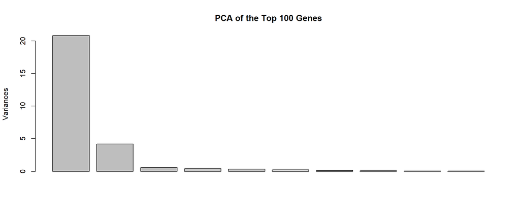

```r
# plot the PCA
plot(top100_pca, main = "PCA of the Top 100 Genes")
```

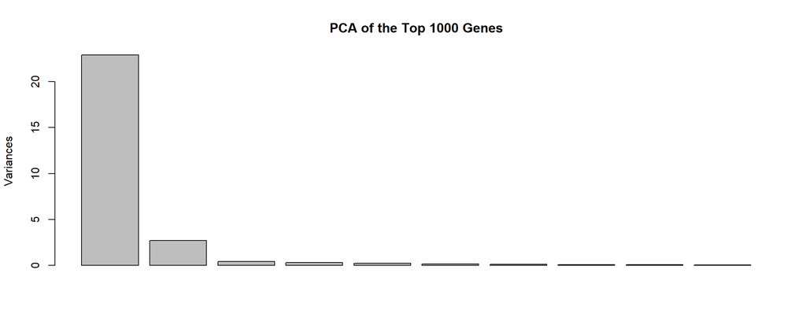

```r
plot(top1k_pca, main = "PCA of the Top 1000 Genes")
```

## 2.2 PCA analysis on top 100 and top 1000 *normalized* data

Repeat this analysis with normalized data and compare the results. Describe which version produces the best results and explain why.

```r
## perform PCA on normalized top 100 and 1000 genes

# convert to DGEList
dge100 <- DGEList(counts = as.matrix(top100_genes))
# apply TMM normalization so counts are comparable across samples
# output is a vector of normalization factors
dge100 <- calcNormFactors(dge100, method = "TMM")
# get normalized counts (CPM)
# log2 CPM for PCA
top100_norm <- cpm(dge100, log = TRUE)
# perform PCA
top100_norm_pca <- prcomp(top100_norm)
# view results
top100_norm_pca$x[1:5, 1:5]
```

```
##          PC1       PC2        PC3         PC4        PC5
## 1 -12.654043 -4.502584  1.5273567  0.01541519  0.2110539
## 2 -14.830566  1.825207  0.8505543 -0.72463473 -0.3262027
## 3  -7.722716 -6.254508 -0.7039579 -0.87611916 -0.2706544
## 4  -9.904387 -4.827347 -0.1923272 -0.77645517 -0.2594412
## 5  -6.599342 -6.475775 -0.9555148 -1.13365565 -0.3712950
```

```r
# convert to DGEList
dge.1k <- DGEList(counts = as.matrix(top1k_genes))
# apply TMM normalization so counts are comparable across samples
# output is a vector of normalization factors
dge.1k <- calcNormFactors(dge.1k, method = "TMM")
# get normalized counts (CPM)
# log2 CPM for PCA
top1k_norm <- cpm(dge.1k, log = TRUE)
# perform PCA
top1k_norm_pca <- prcomp(top1k_norm)
# view results
top1k_norm_pca$x[1:5, 1:5]
```

```
##         PC1       PC2        PC3         PC4       PC5
## 1 -24.65391  4.109479 -0.1591710  1.08075594 0.5639939
## 2 -26.22684 -2.478596  0.1787112  0.83131061 1.1825756
## 3 -19.73935  5.874680 -2.1014638 -0.34805340 1.0814996
## 4 -21.82564  4.342435 -1.6676344  0.04230836 0.9123853
## 5 -18.60718  6.096869 -2.6152275 -0.49045556 1.1314455
```

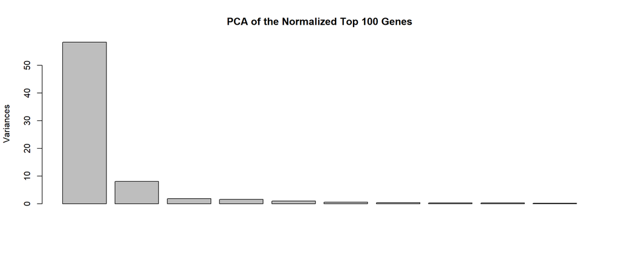

```r
# plot the PCA
plot(top100_norm_pca, main = "PCA of the Normalized Top 100 Genes")
```

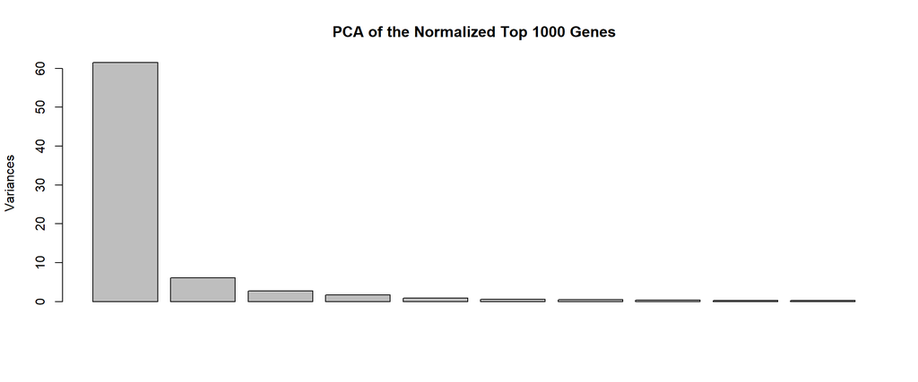

```r
plot(top1k_norm_pca, main = "PCA of the Normalized Top 1000 Genes")
```

## 2.3 3D Representation of PCA Analysis

```r
## Create a function for 3D PCA plotting of multiple datasets

# this function takes multiple datasets and generates 3D PCA plots for each
plot_3d_pca_multiple <- function(datasets, dataset_names, scale_data = TRUE,
                                 highlight_3d = TRUE, cex_symbol = 2, cex_text = 0.8) {

  # check if datasets and names have the same length
  if (length(datasets) != length(dataset_names)) {
    stop("Number of datasets must match number of dataset names")
  }

  # make results list to store PCA results
  pca_results <- list()

  # Loop through each dataset
  for (i in 1:length(datasets)) {
    cat("Generating 3D PCA plot for:", dataset_names[i], "\n")

    # get current dataset
    current_data <- datasets[[i]]
    current_name <- dataset_names[i]

    tryCatch({
      # transpose the count matrix to look for any potential structure among the samples
      # the function prcomp() performs PCA and scales the data
      pca.rpm <- prcomp(t(current_data), scale = scale_data)

      # the function scatterplot3d() plots the 3D PCA by taking the first 3 principal components
      sc3 <- scatterplot3d(pca.rpm$x[,1:3], pch=20, highlight.3d = highlight_3d,
                          cex.symbol = cex_symbol,
                          main = paste("3D PCA Plot of", current_name, "(Samples)"))

      # convert 3D coordinates to 2D for text placement
      s3d.coords <- sc3$xyz.convert(pca.rpm$x[,1:3])

      # add the sample names to the plot by taking the x & y coordinates and the sample names
      text(s3d.coords$x, s3d.coords$y, labels=colnames(current_data),
           pos=4, cex=cex_text)

      # store PCA results in the list object
      pca_results[[current_name]] <- list(
        pca_object = pca.rpm,
        explained_variance = summary(pca.rpm)$importance[2, 1:3],  # First 3 PCs
        total_variance_explained = sum(summary(pca.rpm)$importance[2, 1:3])
      )

      cat("  - 3D PCA plot generated successfully\n")
      cat("  - Variance explained by first 3 PCs:",
          round(pca_results[[current_name]]$total_variance_explained * 100, 2), "%\n")

    }, error = function(e) {
      cat("  - Error generating 3D PCA plot:", e$message, "\n")
      pca_results[[current_name]] <- paste("Error:", e$message)
    })
  }

  # return PCA results for further analysis if needed
  return(pca_results)
}

# get all the data sets for 3D PCA analysis
datasets_for_3d <- list(
  top100_genes,
  top1k_genes,
  top100_norm,
  top1k_norm
)

# assign names for the data sets that will become plot titles
dataset_names_for_3d <- c(
  "Top 100 Genes",
  "Top 1000 Genes",
  "Top 100 Normalized",
  "Top 1000 Normalized"
)

# generate 3D PCA plots for all data sets by executing the function
cat("Starting 3D PCA analysis for multiple datasets...\n")
```

```
## Starting 3D PCA analysis for multiple datasets...
```

```
## Generating 3D PCA plot for: Top 100 Genes
```

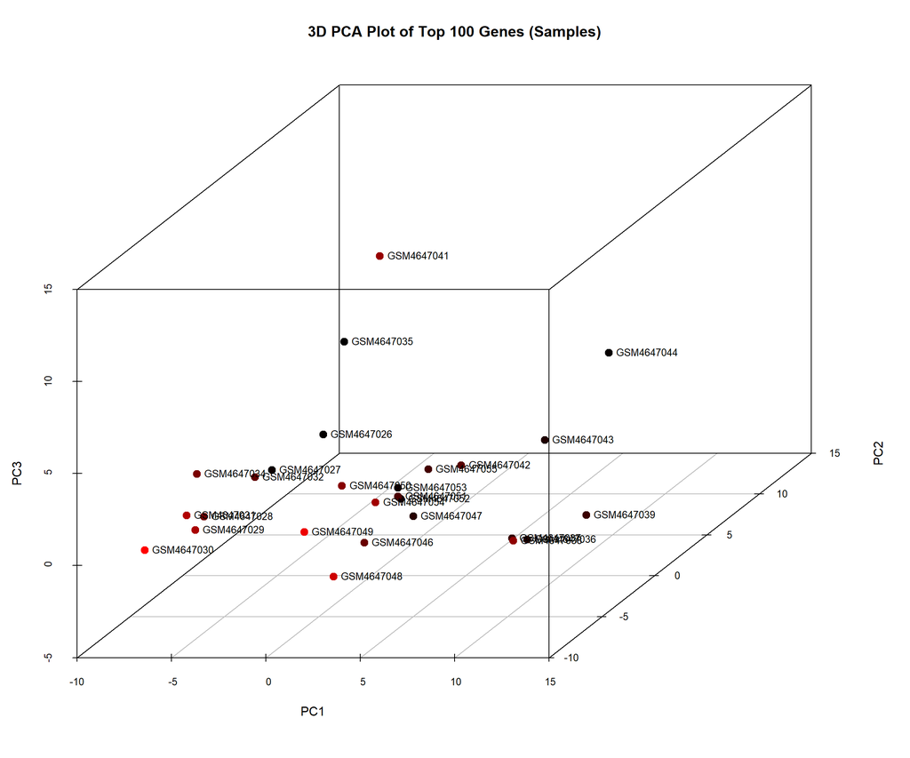

```
##   - 3D PCA plot generated successfully
##   - Variance explained by first 3 PCs: 69.25 %
## Generating 3D PCA plot for: Top 1000 Genes
```

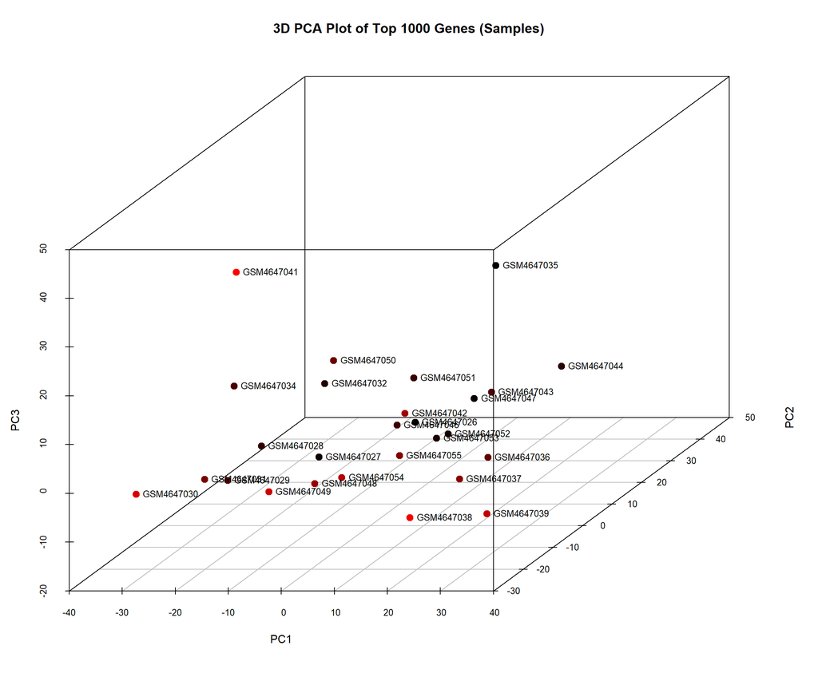

```
##   - 3D PCA plot generated successfully
##   - Variance explained by first 3 PCs: 69.05 %
## Generating 3D PCA plot for: Top 100 Normalized
```

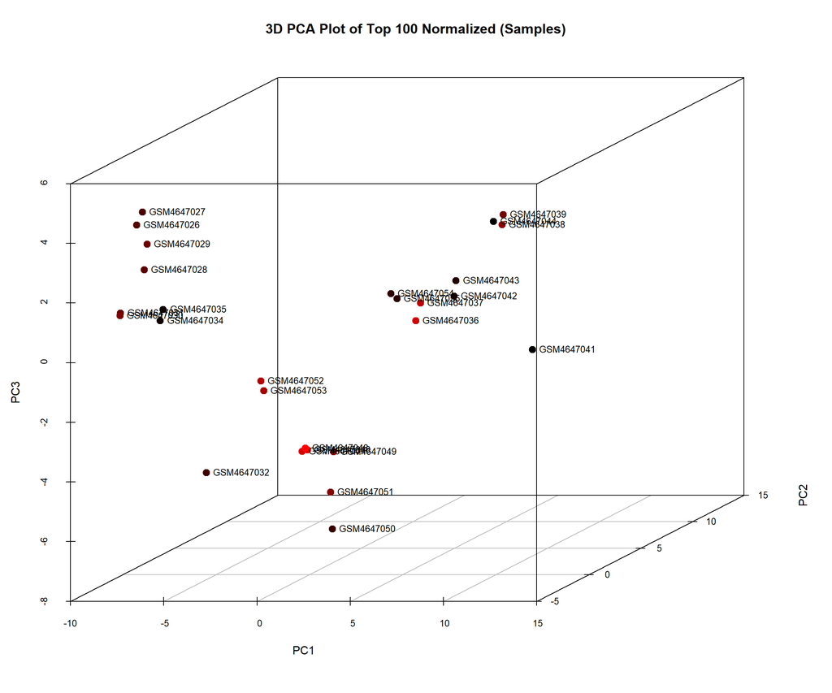

```
##   - 3D PCA plot generated successfully
##   - Variance explained by first 3 PCs: 71.81 %
## Generating 3D PCA plot for: Top 1000 Normalized
```

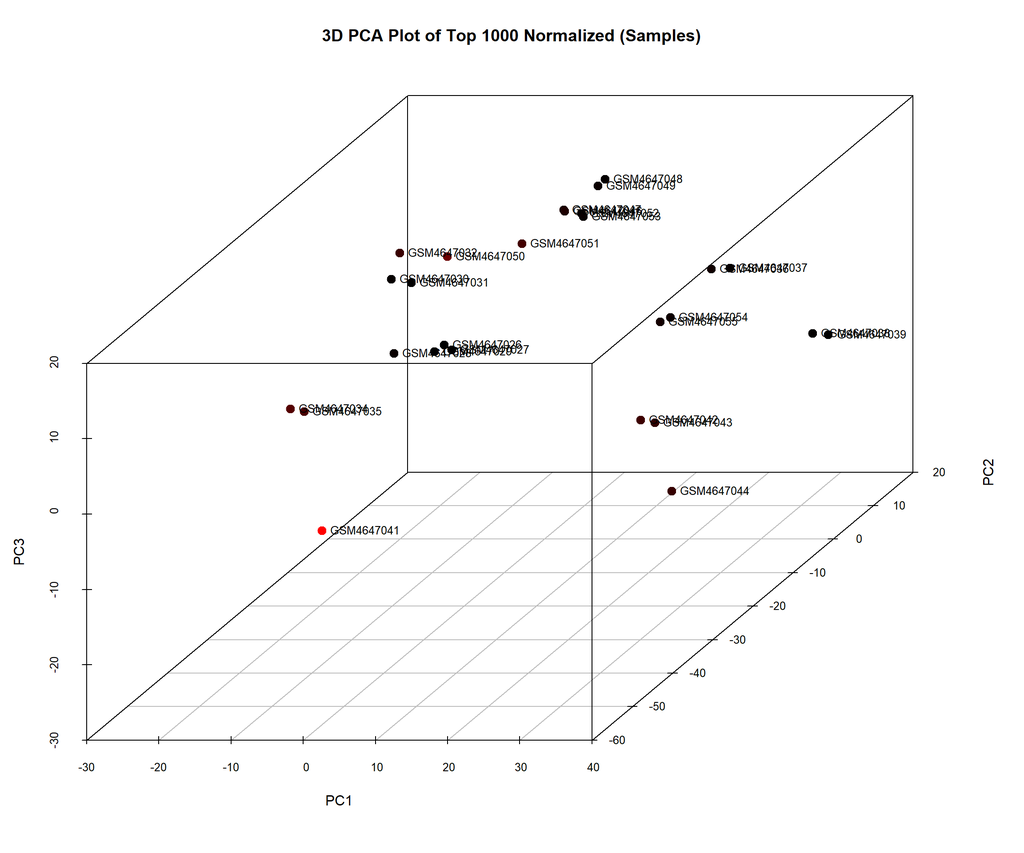

```
##   - 3D PCA plot generated successfully
##   - Variance explained by first 3 PCs: 68.62 %
```

```r
pca_3d_results <- plot_3d_pca_multiple(
  # call on the data sets being analyzed
  datasets = datasets_for_3d,
  # call on the names of the data sets
  dataset_names = dataset_names_for_3d,
  # parameter is set to scale each dataset
  scale_data = TRUE,
  # color the data points
  highlight_3d = TRUE,
  # size of data points
  cex_symbol = 2,
  # text size
  cex_text = 0.8
)
```